# EV Infrastructure Analysis - Modeling

import libraries

```r
library(tidyverse)
library(dplyr)
library(janitor)
library(Hmisc)
library(ggplot2)
```

import data from preprocessing

```r
ev_data_by_state <- read_csv("data/ev_data_by_state.csv")
ev_data_by_state
```

| ...1 | state | total_stations | registration_count | population | evs_per_station | people_per_station | pop_with_ev |
| --- | --- | --- | --- | --- | --- | --- | --- |
| 1 | CA | 17797 | 1256646 | 39555674 | 70.61 | 2222.60 | 0.0318 |
| 2 | WA | 2643 | 152101 | 7707586 | 57.55 | 2916.23 | 0.0197 |
| 3 | HI | 383 | 25565 | 1455252 | 66.75 | 3799.61 | 0.0176 |
| 4 | CO | 2495 | 90083 | 5775324 | 36.11 | 2314.76 | 0.0156 |
| 5 | NV | 610 | 47361 | 3105595 | 77.64 | 5091.14 | 0.0153 |
| 6 | OR | 1464 | 64361 | 4237224 | 43.96 | 2894.28 | 0.0152 |
| 7 | NJ | 1586 | 134753 | 9289014 | 84.96 | 5856.88 | 0.0145 |
| 8 | AZ | 1454 | 89798 | 7158110 | 61.76 | 4923.05 | 0.0125 |
| 9 | UT | 923 | 39998 | 3271608 | 43.33 | 3544.54 | 0.0122 |
| 10 | VT | 486 | 7816 | 643082 | 16.08 | 1323.21 | 0.0122 |

[output cut: 40 more lines]

```r
ev_stations_locations <- read_csv("data/ev_station_locations.csv")
ev_stations_locations
```

| ...1 | station_name | city | state | zip | country | latitude | longitude | ev_network |
| --- | --- | --- | --- | --- | --- | --- | --- | --- |
| 1 | Los Angeles Convention Center | Los Angeles | CA | 90015 | US | 34.04054 | -118.27139 | Non-Networked |
| 2 | Scripps Green Hospital | La Jolla | CA | 92037 | US | 32.89947 | -117.24300 | Non-Networked |
| 3 | Galpin Motors | Sepulveda | CA | 91343 | US | 34.22167 | -118.46837 | Non-Networked |
| 4 | Galleria at Tyler | Riverside | CA | 92503 | US | 33.90991 | -117.45905 | Non-Networked |
| 5 | City of Pasadena - Holly Street Garage | Pasadena | CA | 91103 | US | 34.14762 | -118.14711 | Non-Networked |
| 6 | City of Pasadena - De Lacey Garage | Pasadena | CA | 91105 | US | 34.14514 | -118.15265 | Non-Networked |
| 7 | City of Pasadena - Schoolhouse Garage | Pasadena | CA | 91105 | US | 34.14512 | -118.15013 | Non-Networked |
| 8 | Hyatt Regency Long Beach | Long Beach | CA | 90802 | US | 33.76370 | -118.19200 | Non-Networked |
| 9 | Los Angeles International Airport (LAX) - Lot 6 | Los Angeles | CA | 90045 | US | 33.94325 | -118.40334 | Non-Networked |
| 10 | Northridge Fashion Center East Garage Lower Level | Northridge | CA | 91324 | US | 34.23872 | -118.55469 | SHELL_RECHARGE |

[output cut: 990 more lines]

differentiate column names

```r
ev_data_by_state <- ev_data_by_state |>
  rename(ev_stations = total_stations,
         ev_registrations = registration_count)
ev_data_by_state
```

| ...1 | state | ev_stations | ev_registrations | population | evs_per_station | people_per_station | pop_with_ev |
| --- | --- | --- | --- | --- | --- | --- | --- |
| 1 | CA | 17797 | 1256646 | 39555674 | 70.61 | 2222.60 | 0.0318 |
| 2 | WA | 2643 | 152101 | 7707586 | 57.55 | 2916.23 | 0.0197 |
| 3 | HI | 383 | 25565 | 1455252 | 66.75 | 3799.61 | 0.0176 |
| 4 | CO | 2495 | 90083 | 5775324 | 36.11 | 2314.76 | 0.0156 |
| 5 | NV | 610 | 47361 | 3105595 | 77.64 | 5091.14 | 0.0153 |
| 6 | OR | 1464 | 64361 | 4237224 | 43.96 | 2894.28 | 0.0152 |
| 7 | NJ | 1586 | 134753 | 9289014 | 84.96 | 5856.88 | 0.0145 |
| 8 | AZ | 1454 | 89798 | 7158110 | 61.76 | 4923.05 | 0.0125 |
| 9 | UT | 923 | 39998 | 3271608 | 43.33 | 3544.54 | 0.0122 |
| 10 | VT | 486 | 7816 | 643082 | 16.08 | 1323.21 | 0.0122 |

[output cut: 40 more lines]

set random seed

```r
set.seed(42)
```

I believe it is a fair assumption to say that the average person does not worry about where to fuel up when driving an internal combustion engine (ICE) vehicle. Unless driving in extremely rural areas, gas stations are readily available, have enough pumps, and experience minimal downtime. Let’s do a better job predicting how many EVs each state will need based on the current gasoline infrastructure.

Gas Station Data: https://afdc.energy.gov/files/u/data/data_source/10333/10333_gasoline_stations_year.xlsx Caveat: data only through 2012 (historical trends show a decline in number of gas stations since 1996)

import and clean up data

```r
gas_stations <- read.csv("data/2012_gas_stations_us.csv")

gas_stations <- gas_stations |>
  rename(gas_stations = X2012) |>
  rename(state = State)

gas_stations$state <- state.abb[match(gas_stations$state, state.name)]
gas_stations
```

| state | gas_stations |
| --- | --- |
| AL | 6300 |
| AK | 361 |
| AZ | 2027 |
| AR | 2107 |
| CA | 10100 |
| CO | 2188 |
| CT | 1488 |
| DE | 419 |
| FL | 9037 |
| GA | 8471 |

[output cut: 41 more lines]

join with state-level data for analysis

```r
ev_data_by_state <- ev_data_by_state |>
  left_join(gas_stations) |>
  mutate(ev_gas_difference = gas_stations - ev_stations) |>
  arrange(desc(ev_gas_difference))
ev_data_by_state
```

| ...1 | state | ev_stations | ev_registrations | population | evs_per_station | people_per_station | pop_with_ev | gas_stations | ev_gas_difference |
| --- | --- | --- | --- | --- | --- | --- | --- | --- | --- |
| 18 | TX | 3834 | 230125 | 29149458 | 60.02 | 7602.88 | 0.0079 | 13715 | 9881 |
| 16 | GA | 2173 | 92368 | 10713755 | 42.51 | 4930.40 | 0.0086 | 8471 | 6298 |
| 43 | AL | 506 | 13047 | 5025369 | 25.78 | 9931.56 | 0.0026 | 6300 | 5794 |
| 11 | FL | 3801 | 254878 | 21538192 | 67.06 | 5666.45 | 0.0118 | 9037 | 5236 |
| 21 | NC | 1863 | 70164 | 10441499 | 37.66 | 5604.67 | 0.0067 | 6270 | 4407 |
| 47 | LA | 282 | 8150 | 4657874 | 28.90 | 16517.28 | 0.0017 | 3696 | 3414 |
| 30 | TN | 1050 | 33221 | 6912347 | 31.64 | 6583.19 | 0.0048 | 4400 | 3350 |
| 35 | WI | 749 | 24943 | 5894170 | 33.30 | 7869.39 | 0.0042 | 3682 | 2933 |
| 28 | MI | 1822 | 50284 | 10079338 | 27.60 | 5532.02 | 0.0050 | 4749 | 2927 |
| 24 | OK | 380 | 22843 | 3959405 | 60.11 | 10419.49 | 0.0058 | 3200 | 2820 |

[output cut: 40 more lines]

factor in geographic area to the model

import state geographic data and convert to state abbreviations State Area Data: https://www.census.gov/geographies/reference-files/2010/geo/state-area.html

```r
state_areas <- read.csv("data/state_areas.csv")
state_areas$state <- state.abb[match(state_areas$state, state.name)]
state_areas
```

| state | sq_mi |
| --- | --- |
| AL | 52420 |
| AK | 665384 |
| AZ | 113990 |
| AR | 53179 |
| CA | 163695 |
| CO | 104094 |
| CT | 5543 |
| DE | 2489 |
| FL | 65758 |
| GA | 59425 |

[output cut: 40 more lines]

join the datasets

```r
ev_data_by_state <- ev_data_by_state |>
  left_join(state_areas) |>
  arrange(desc(sq_mi))
ev_data_by_state
```

| ...1 | state | ev_stations | ev_registrations | population | evs_per_station | people_per_station | pop_with_ev | gas_stations | ev_gas_difference | sq_mi |
| --- | --- | --- | --- | --- | --- | --- | --- | --- | --- | --- |
| 39 | AK | 63 | 2697 | 733395 | 42.81 | 11641.19 | 0.0037 | 361 | 298 | 665384 |
| 18 | TX | 3834 | 230125 | 29149458 | 60.02 | 7602.88 | 0.0079 | 13715 | 9881 | 268596 |
| 1 | CA | 17797 | 1256646 | 39555674 | 70.61 | 2222.60 | 0.0318 | 10100 | -7697 | 163695 |
| 33 | MT | 142 | 4608 | 1084216 | 32.45 | 7635.32 | 0.0043 | 558 | 416 | 147040 |
| 29 | NM | 401 | 10276 | 2117555 | 25.63 | 5280.69 | 0.0049 | 1188 | 787 | 121590 |
| 8 | AZ | 1454 | 89798 | 7158110 | 61.76 | 4923.05 | 0.0125 | 2027 | 573 | 113990 |
| 5 | NV | 610 | 47361 | 3105595 | 77.64 | 5091.14 | 0.0153 | 1036 | 426 | 110572 |
| 4 | CO | 2495 | 90083 | 5775324 | 36.11 | 2314.76 | 0.0156 | 2188 | -307 | 104094 |
| 6 | OR | 1464 | 64361 | 4237224 | 43.96 | 2894.28 | 0.0152 | 2010 | 546 | 98379 |
| 45 | WY | 102 | 1139 | 576844 | 11.17 | 5655.33 | 0.0020 | 299 | 197 | 97813 |

[output cut: 40 more lines]

predict the number of stations that each state should have based on various factors model: generalized linear model (necessary based on counts)

```r
model_poisson = glm(ev_stations ~ ev_registrations + population + gas_stations + sq_mi,
                    data = ev_data_by_state,
                    family = poisson(link = "log"))
summary(model_poisson)
```

```
Call:
glm(formula = ev_stations ~ ev_registrations + population + gas_stations +
    sq_mi, family = poisson(link = "log"), data = ev_data_by_state)

Coefficients:
                   Estimate Std. Error z value Pr(>|z|)
(Intercept)       6.490e+00  7.164e-03 905.805  < 2e-16 ***
ev_registrations -3.000e-07  2.742e-08 -10.940  < 2e-16 ***
population        1.165e-07  1.539e-09  75.672  < 2e-16 ***
gas_stations     -2.111e-05  3.417e-06  -6.178 6.49e-10 ***
sq_mi            -4.281e-06  8.741e-08 -48.980  < 2e-16 ***
---
Signif. codes:  0 ‘***’ 0.001 ‘**’ 0.01 ‘*’ 0.05 ‘.’ 0.1 ‘ ’ 1

(Dispersion parameter for poisson family taken to be 1)

    Null deviance: 107194  on 49  degrees of freedom
Residual deviance:  16492  on 45  degrees of freedom
AIC: 16924

Number of Fisher Scoring iterations: 5
```

add model findings to dataset new features: expected stations (predicted from model) and station gap (expected - existing)

```r
ev_data_by_state <- ev_data_by_state |>
  mutate(
    expected_stations = round(predict(model_poisson, type = "response"), 0),
    station_gap = expected_stations - ev_stations) |>
  arrange(desc(station_gap))
ev_data_by_state
```

| ...1 | state | ev_stations | ev_registrations | population | evs_per_station | people_per_station | pop_with_ev | gas_stations | ev_gas_difference | sq_mi | expected_stations | station_gap |
| --- | --- | --- | --- | --- | --- | --- | --- | --- | --- | --- | --- | --- |
| 11 | FL | 3801 | 254878 | 21538192 | 67.06 | 5666.45 | 0.0118 | 9037 | 5236 | 65758 | 4673 | 872 |
| 47 | LA | 282 | 8150 | 4657874 | 28.90 | 16517.28 | 0.0017 | 3696 | 3414 | 52378 | 835 | 553 |
| 48 | WV | 183 | 2758 | 1793736 | 15.07 | 9801.84 | 0.0015 | 1353 | 1170 | 24230 | 710 | 527 |
| 42 | KY | 354 | 11617 | 4506302 | 32.82 | 12729.67 | 0.0026 | 2922 | 2568 | 40408 | 877 | 523 |
| 49 | MS | 195 | 3590 | 2961278 | 18.41 | 15186.04 | 0.0012 | 2926 | 2731 | 48432 | 709 | 514 |
| 18 | TX | 3834 | 230125 | 29149458 | 60.02 | 7602.88 | 0.0079 | 13715 | 9881 | 268596 | 4344 | 510 |
| 19 | IL | 1546 | 99573 | 12821814 | 64.41 | 8293.54 | 0.0078 | 3875 | 2329 | 57914 | 2046 | 500 |
| 37 | IN | 659 | 26101 | 6786587 | 39.61 | 10298.31 | 0.0038 | 3069 | 2410 | 36420 | 1155 | 496 |
| 17 | DE | 239 | 8435 | 989955 | 35.29 | 4142.07 | 0.0085 | 419 | 180 | 2489 | 723 | 484 |
| 20 | NH | 286 | 9861 | 1377546 | 34.48 | 4816.59 | 0.0072 | 857 | 571 | 9349 | 727 | 441 |

[output cut: 40 more lines]

visualize station gap from model

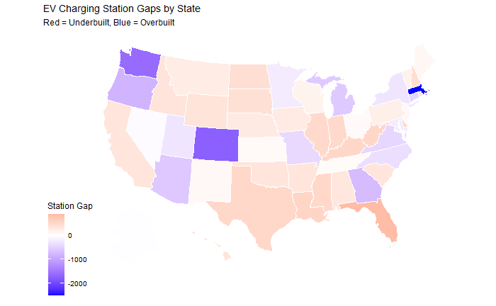

```r
plot_usmap(data = ev_data_by_state, values = "station_gap", color = "white") +
  scale_fill_gradient2(
    low = "blue", mid = "white", high = "red",
    midpoint = 0, name = "Station Gap"
  ) +
  labs(
    title = "EV Charging Station Gaps by State",
    subtitle = "Red = Underbuilt, Blue = Overbuilt"
  )

ggsave("outputs/modeling/underbuilt_states_map.png", bg = "skyblue")
```

visualize top 10 underbuilt states as predicted by model

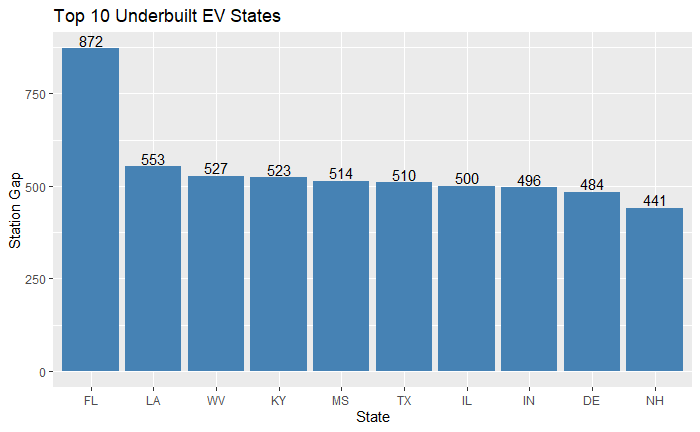

```r
ev_data_by_state_10 <- ev_data_by_state |>
  head(10)

ggplot(ev_data_by_state_10, aes(x = reorder(state, -station_gap), y = station_gap)) +
  geom_bar(stat = "identity", fill = "steelblue") +
  labs(
    title = "Top 10 Underbuilt EV States",
    x = "State",
    y = "Station Gap"
  ) +
  geom_text(aes(label = station_gap), vjust = -0.2)

ggsave("outputs/modeling/top_underbuilt_states.png")
```

save top underbuilt states for geospatial analysis

```r
number_of_states <- 5

underbuilt_state_list <- ev_data_by_state |>
  arrange(desc(station_gap)) |>
  head(number_of_states) |>
  pull(state)
underbuilt_state_list

write_rds(underbuilt_state_list, "data/underbuilt_states.rds")
```